# RD Robustness Project

Exercise: stressout before replacing with zeros

Matthew Hong & Maor Milgrom

2020-12-30

# Introduction

The goal of this project is to test the robustness of the Regression-Discontinuity analysis to different extreme cases, via simulations, using the ‘rdrobust’ package.

## This Document: Excercise #2

Stressing out results, by adding noise inside Optimal Bandwitdh (OBW), before repeating exercise #1.

### Select exercise type:

```r
exercise=params$exercise      # Type of exercise - "zero" or "bwo" ('bandwidth only')
```

### Set Parameters

Here we set the main parameters for the excercise:

```r
jump=10           # Size of jump at cutoff
loop=1000
figs.iter.save=5
quadratic=T       # T - quadratic DGP, F - linear
symm_obw="mserd"  # mserd - symmetric OBW, msetwo - asymmetric OBW
normal.x=T        # T - normal draws of x around cutoff, F - uniform draws
dgp.sd=10         # sd of normal noise added to DGP
noisy.sd=30       # sd of noise added inside OBW
so.int=2          # interval inside OBW for adding noise
bc=F              # bias-corrected estimates or conventional
```

### Simulate DGP

```r
dt <- as.data.table(matrix(0, ncol = 0, nrow = length(seq(-100,100,0.01))))
dt$x <- round(seq(-100,100,0.01), digits=2)
dt <- dt[x!=0]
dt$treated <- ifelse(dt$x>0, 1, 0)

dt$y.model<- 0.5*dt$x  - 0.025*dt$x^2*quadratic + jump*dt$treated
dt$y <- dt$y.model + rnorm(length(dt$x),0,dgp.sd)
dt$y.noisy <- dt$y + rnorm(length(dt$x),0,noisy.sd)

## dataframe for draws (samples)
sample.x <- as.data.table(matrix(0, ncol = 0, nrow = nrow(dt)/10))
```

### Iterations

Running 1000 iterations, and saving figures from 5 last iterations to file. In each iteration, we:

1. draw randomly 2000 observations around the cutoff.
2. compute the OBW and RD coefficient
3. Add noise just inside OBW (within 2 units)
4. compute again the OBW and RD coefficient
5. drop observations outside the new OBW/replace them with zero
6. compute again the OBW and RD coefficient.

### Presenting figures from last iteration for illustration

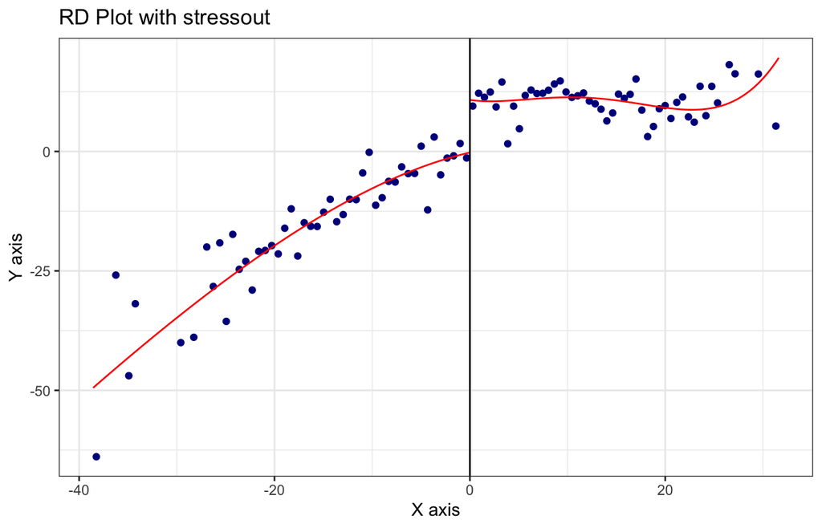

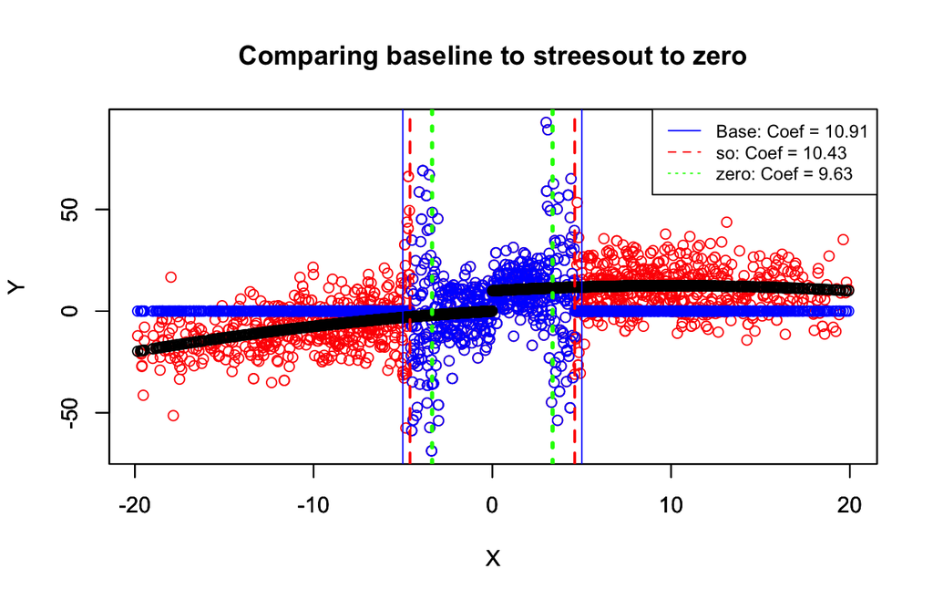

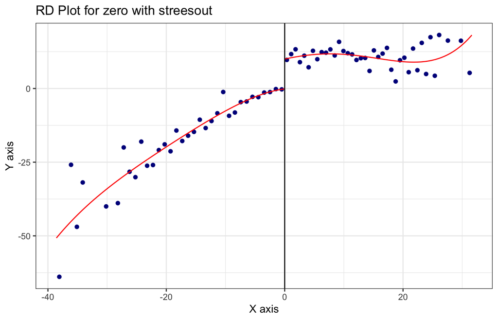

## Results

### Figures summarizing iterations

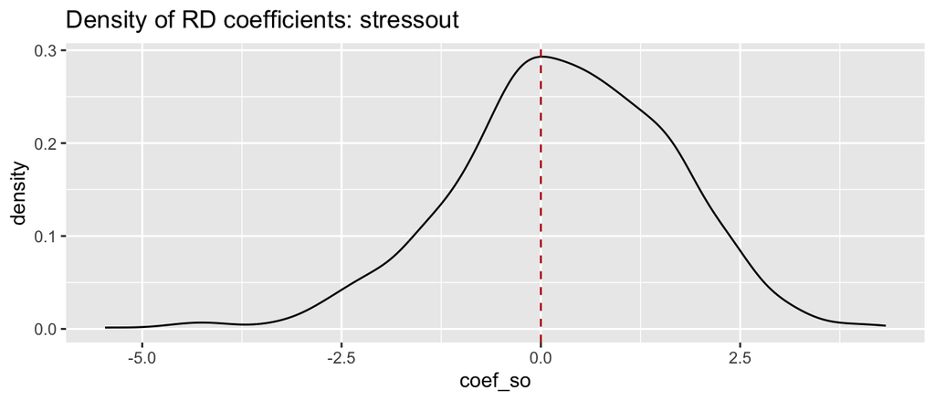

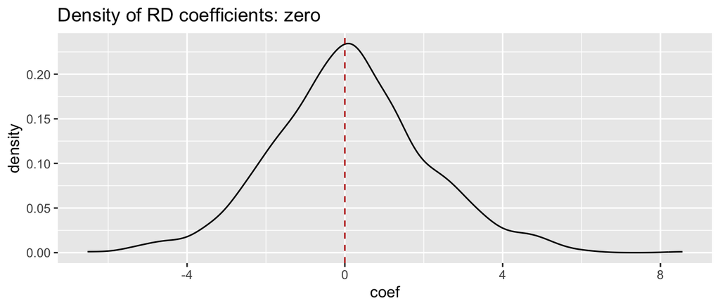

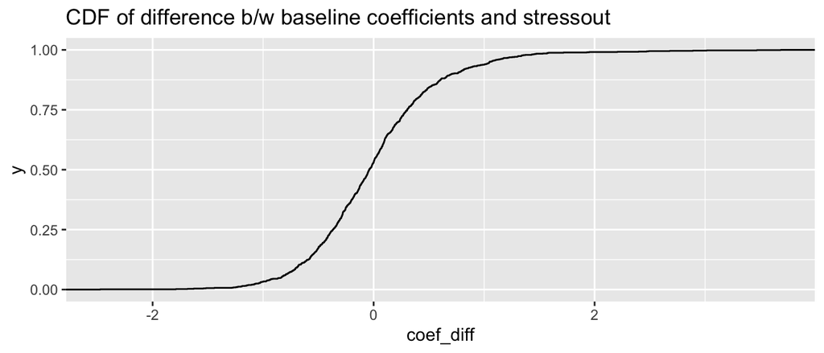

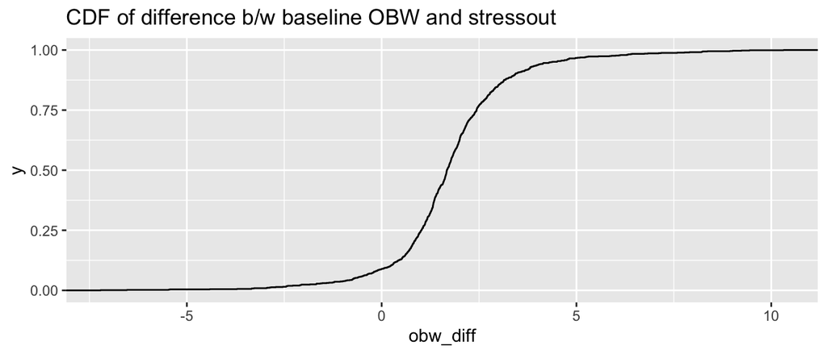

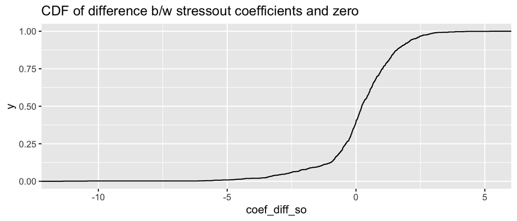

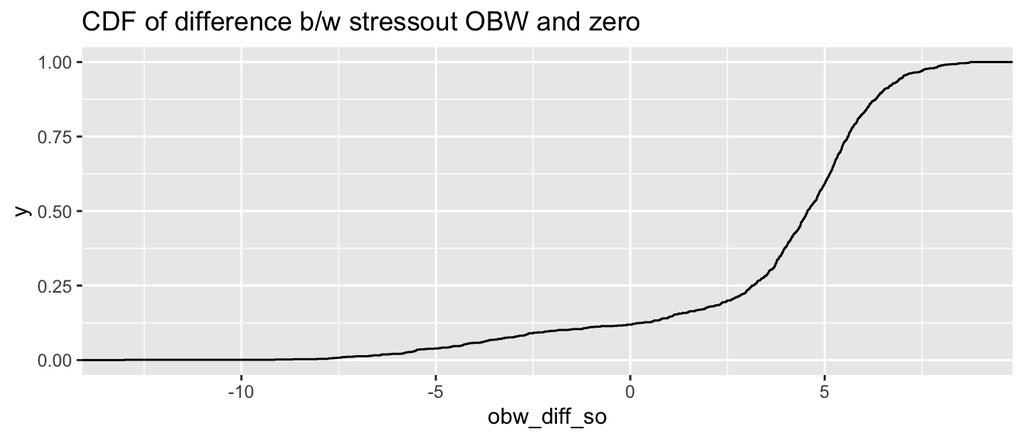

### Summary results - Table

Note: coefficient (treatment effects) are normalized to zero, by subtracting from each estimate the size of the jump at the cutoff.

Summary Table

| base | stressout | zero | diff_base | diff_so |
| --- | --- | --- | --- | --- |
| 0.2867 | 0.2820 | 0.1203 | 0.1664 | 0.1617 |
| 13.1066 | 11.3491 | 7.6856 | 5.4210 | 3.6635 |

### Interpreting results

Adding noise within OBW leads to new OBW to be narrower, but coefficients remain unbiased. Then, when replacing values outside new OBW with zeros, the estimated coefficients remain unbiased